# Class 19: Model/Variable Selection

Hughes/Fisher

## Model Selection

**Model selection** is the act of selecting a statistical model from a set of candidate models and/or predictor variables. That is, in a given problem where you are looking to build a model for a response variable $Y$ and you have a set of possible predictor variables $X_1$, $X_2$, $X_3$, $\ldots$, how do you choose the best model?

The area of **model selection** continues to augment and connects classic statistics to machine learning and data science. We only scratch the surface here. For more information, feel free to consult the source of all knowledge, Wikipedia!

https://en.wikipedia.org/wiki/Model_selection

## Data: predictors of rock strength

The file `rockstrength.csv` contains the uniaxial compressive strength (`UCS`) of 30 rocks/minerals along with 8 potential predictor variables: Percentage Quartz (`quartz`), Percentage Plagioclase (`plag`), Percentage K. feldspar (`kfds`), Percentage Hornblende (`hb`), Grain size in mm (`gs`), grain area in mm^2 (`ga`), shape factor (`sf`) and aspect ratio (`ar`).

We will consider this data as a working example. First, read the data.

```r
rocks <- read.csv("rockstrength.csv")
head(rocks)
```

```
##   sample_id   UCS quartz plag  kfds    hb    gs     ga    sf    ar
## 1         1 100.6   40.3 9.98 17.01 21.57 0.031  754.4 0.594 0.630
## 2         2 112.0   47.1 8.50 15.00 23.00 0.025  490.6 0.612 0.612
## 3         3 117.5   45.4 9.10 16.20 24.00 0.022  379.9 0.628 0.628
## 4         4 100.9   41.3 7.72 11.02 18.86 0.044 1519.8 0.571 0.667
## 5         5  94.5   33.8 4.10 14.00 16.00 0.043 1451.5 0.575 0.662
## 6         6  91.5   37.2 7.40 12.00 13.00 0.046 1661.1 0.499 0.663
```

### Visualize the data

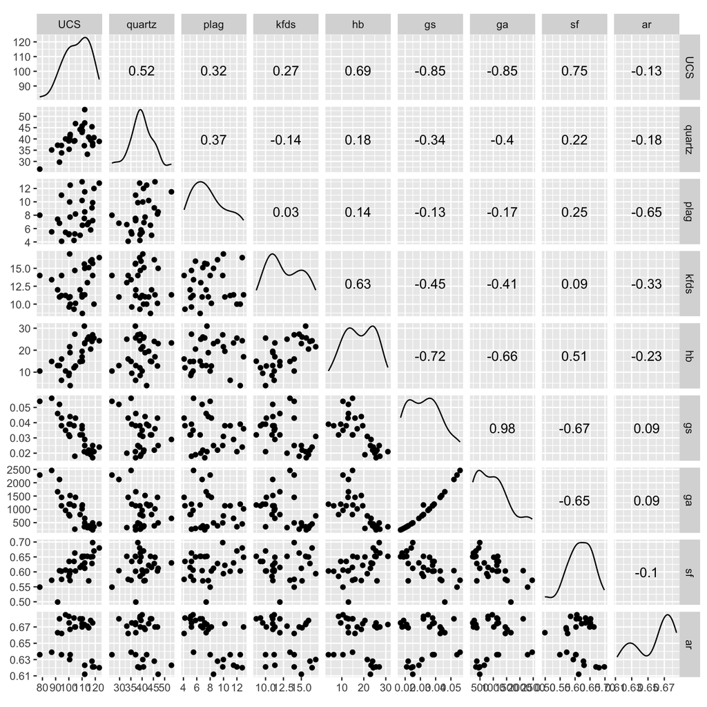

```r
ggscatmat(rocks, columns=c(-1)) # Do not plot the ID values. Not meaningful
```

Many variables appear correlated with `UCS` (namely, `quartz`, `hb`, `gs`, `ga` and `sf`).

### Fit a full main effects model

We begin by fitting a full main effects model using all predictor variables:

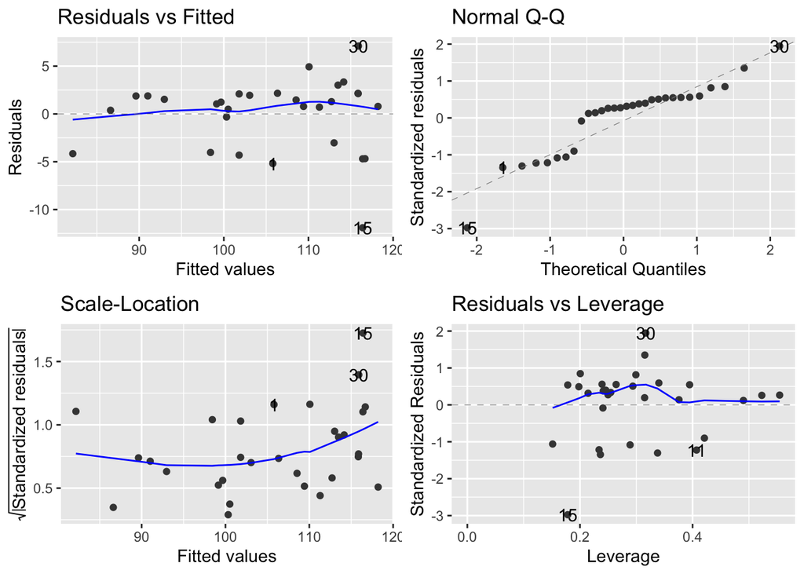

```r
full.fit <- lm(UCS ~ quartz + plag + kfds + hb + gs + ga + sf + ar, data=rocks)
autoplot(full.fit)
```

There is a little bit of goofiness in the Residuals vs Fitted plot and Scale-Location plot, indicating the variance may be increasing with the mean. However, linearity and normality look okay. A Box-Cox plot has been excluded here but suggests that no transformation is necessary. So overall, we feel it is reasonable to proceed with using the model for inference purposes.

```r
summary(full.fit)
```

```
##
## Call:
## lm(formula = UCS ~ quartz + plag + kfds + hb + gs + ga + sf +
##     ar, data = rocks)
##
## Residuals:
##     Min      1Q  Median      3Q     Max
## -11.900  -2.348   1.139   2.054   7.098
##
## Coefficients:
##               Estimate Std. Error t value Pr(>|t|)
## (Intercept)  1.591e+01  4.891e+01   0.325   0.7481
## quartz       4.387e-01  2.055e-01   2.135   0.0447 *
## plag         6.439e-01  4.586e-01   1.404   0.1749
## kfds        -1.661e-01  5.516e-01  -0.301   0.7663
## hb           3.567e-01  2.092e-01   1.705   0.1029
## gs          -3.214e+02  5.459e+02  -0.589   0.5622
## ga          -1.899e-03  9.180e-03  -0.207   0.8381
## sf           6.473e+01  2.991e+01   2.164   0.0421 *
## ar           5.373e+01  5.091e+01   1.056   0.3032
## ---
## Signif. codes:  0 '***' 0.001 '**' 0.01 '*' 0.05 '.' 0.1 ' ' 1
##
## Residual standard error: 4.411 on 21 degrees of freedom
## Multiple R-squared:  0.8766, Adjusted R-squared:  0.8296
## F-statistic: 18.65 on 8 and 21 DF,  p-value: 6.494e-08
```

We note that only `quartz` and `sf` appear as significant predictors for `UCS` when accounting for the other variables. Based on these results and the scatterplot matrix above, we suspect multicollinearity could be influencing our model. We can check that by looking at the Variance Inflation Factors (VIFs):

```r
vif(full.fit)
```

```
##    quartz      plag      kfds        hb        gs        ga        sf        ar
##  1.794627  2.243152  2.720359  3.307093 54.958920 48.171328  2.413303  2.213782
```

As suspected, there are issues with `gs` and `ga` (note the scatterplot matrix again!). Not surprising.

So chances are, only one of `gs` or `ga` is contributing meaningful information to our model (look at the data description – they are essentially the same!).

## Information Criterion

Besides looking at $R^2_a$ and the residual standard error, another method to compare models is via an *Information Criteria*. Two popular techniques are **Akaike Information Criteria (AIC)** and **Bayesian-Schwarz Information Criteria (BIC)**. These methods are similar to $R^2_a$ in that they balance goodness-of-fit (small residual error) with a penalty term for including extraneous variables. The respective equations are
$$AIC = n\log(RSS/n) + 2p, ~~~~~ BIC = n\log(RSS/n) + \log(n)p$$
where $RSS$ is the residual sum of squares, $n$ is the sample size and $p$ is the number of parameters fit (essentially the number of $\beta$-terms). **In general, we prefer models with a small AIC or BIC value** (similar to wanting a larger $R^2_a$). We can extract the AIC and BIC for a given model using the `AIC()` and `BIC()` functions. Consider the following examples:

```r
fit1 <- lm(UCS ~ quartz + gs, data=rocks)
fit2 <- lm(UCS ~ quartz + ga, data=rocks)
fit3 <- lm(UCS ~ quartz + gs + ga, data=rocks)
summary(fit1)
```

```
##
## Call:
## lm(formula = UCS ~ quartz + gs, data = rocks)
##
## Residuals:
##      Min       1Q   Median       3Q      Max
## -11.8908  -3.3239   0.7044   2.4809  11.1761
##
## Coefficients:
##              Estimate Std. Error t value Pr(>|t|)
## (Intercept)  109.2879     8.9979  12.146 1.88e-12 ***
## quartz         0.5188     0.1886   2.751   0.0105 *
## gs          -735.2206    90.5279  -8.121 1.01e-08 ***
## ---
## Signif. codes:  0 '***' 0.001 '**' 0.01 '*' 0.05 '.' 0.1 ' ' 1
##
## Residual standard error: 5.1 on 27 degrees of freedom
## Multiple R-squared:  0.788,  Adjusted R-squared:  0.7722
## F-statistic: 50.17 on 2 and 27 DF,  p-value: 8.069e-10
```

```r
summary(fit2)
```

```
##
## Call:
## lm(formula = UCS ~ quartz + ga, data = rocks)
##
## Residuals:
##     Min      1Q  Median      3Q     Max
## -10.289  -3.095   1.041   3.160  10.964
##
## Coefficients:
##              Estimate Std. Error t value Pr(>|t|)
## (Intercept) 101.83892    8.97107  11.352 8.74e-12 ***
## quartz        0.41648    0.20414   2.040   0.0512 .
## ga           -0.01328    0.00176  -7.543 4.10e-08 ***
## ---
## Signif. codes:  0 '***' 0.001 '**' 0.01 '*' 0.05 '.' 0.1 ' ' 1
##
## Residual standard error: 5.368 on 27 degrees of freedom
## Multiple R-squared:  0.7651, Adjusted R-squared:  0.7477
## F-statistic: 43.96 on 2 and 27 DF,  p-value: 3.22e-09
```

```r
summary(fit3)
```

```
##
## Call:
## lm(formula = UCS ~ quartz + gs + ga, data = rocks)
##
## Residuals:
##      Min       1Q   Median       3Q      Max
## -12.1787  -3.3711   0.5578   2.6239  11.2914
##
## Coefficients:
##               Estimate Std. Error t value Pr(>|t|)
## (Intercept)  1.107e+02  1.009e+01  10.966 3.01e-11 ***
## quartz       5.484e-01  2.118e-01   2.590   0.0155 *
## gs          -9.075e+02  5.304e+02  -1.711   0.0990 .
## ga           3.232e-03  9.798e-03   0.330   0.7441
## ---
## Signif. codes:  0 '***' 0.001 '**' 0.01 '*' 0.05 '.' 0.1 ' ' 1
##
## Residual standard error: 5.186 on 26 degrees of freedom
## Multiple R-squared:  0.7888, Adjusted R-squared:  0.7645
## F-statistic: 32.38 on 3 and 26 DF,  p-value: 6.227e-09
```

Note that in `fit3` we include both variables `gs` and `ga` and the $R^2$ value has increased (granted, not by much) compared to models `fit1` and `fit2`. We also note that the adjusted $R^2$ has actually *decreased* from `fit1` to `fit3`. This indicates the addition of `ga` to a model with `quartz` and `gs` is unecessary. However, moving from `fit2` to `fit3` appears justified. In a similar fashion, we can consider the AIC and BIC values:

```r
AIC(fit1)
```

```
## [1] 187.7303
```

```r
AIC(fit2)
```

```
## [1] 190.8059
```

```r
AIC(fit3)
```

```
## [1] 189.605
```

```r
BIC(fit1)
```

```
## [1] 193.3351
```

```r
BIC(fit2)
```

```
## [1] 196.4107
```

```r
BIC(fit3)
```

```
## [1] 196.611
```

For both AIC and BIC, `fit2` and `fit3` have larger values than `fit1`. Thus we have multiple measures suggesting that `fit1` is the best fit of those considered here.

**NOTE:** $R^2_a$, AIC and BIC do not necessarily pick the same model!

## Stepwise Regression

The above example involving `fit1`, `fit2` and `fit3` is an example of *model selection* (albeit not a complete example). We used $R^2_a$, AIC and BIC to pick a model. You may ask youself, why not try other variables? Perhaps if we added `hb` as a variable onto `fit1`, it would help? What about `plag`? What about `kfds`?

We can algorithmically step through each predictor variable, adding variables (or subtracting them) – this could take a while! Fortunately, a computer is great at doing repetitive tasks, so we can do it.

### Backward selection

The idea is to start a model with all predictors in it (so here, `UCS` is estimated with `quartz`, `plag`, `kfds`, `hb`, `gs`, `ga`, `sf` and `ar`) and the AIC is calulated for this model.

- Each predictor is removed one at a time and the model is refit – so a model with everything except `quartz` is fit. Then a model with everything but `plag` is fit, and so on. The AIC is calculated for each.
- The model that improves AIC (biggest decrease) is selected as the new best model.
- The next step involves removing each remaining variable one at a time looking for an improved AIC (so removing the least important two variables).
- This process continues until the AIC starts to get worse (i.e. when AIC increases).

### Forward selection

The forward selection algorithm is very similar to backward selection but starts with little (or no) variables, and works its way up by adding variables that improve the fit.

In R, backward and forward selection methods are implemented in the functions `step` or `stepAIC` in the `MASS` library.

## Example with rock strength

First, we remind ourselves of the full model fit above.

```r
summary(full.fit)
```

```
##
## Call:
## lm(formula = UCS ~ quartz + plag + kfds + hb + gs + ga + sf +
##     ar, data = rocks)
##
## Residuals:
##     Min      1Q  Median      3Q     Max
## -11.900  -2.348   1.139   2.054   7.098
##
## Coefficients:
##               Estimate Std. Error t value Pr(>|t|)
## (Intercept)  1.591e+01  4.891e+01   0.325   0.7481
## quartz       4.387e-01  2.055e-01   2.135   0.0447 *
## plag         6.439e-01  4.586e-01   1.404   0.1749
## kfds        -1.661e-01  5.516e-01  -0.301   0.7663
## hb           3.567e-01  2.092e-01   1.705   0.1029
## gs          -3.214e+02  5.459e+02  -0.589   0.5622
## ga          -1.899e-03  9.180e-03  -0.207   0.8381
## sf           6.473e+01  2.991e+01   2.164   0.0421 *
## ar           5.373e+01  5.091e+01   1.056   0.3032
## ---
## Signif. codes:  0 '***' 0.001 '**' 0.01 '*' 0.05 '.' 0.1 ' ' 1
##
## Residual standard error: 4.411 on 21 degrees of freedom
## Multiple R-squared:  0.8766, Adjusted R-squared:  0.8296
## F-statistic: 18.65 on 8 and 21 DF,  p-value: 6.494e-08
```

#### Backward selection illustration

```r
step.pick <- step(full.fit, direction="backward")
```

```
## Start:  AIC=96.35
## UCS ~ quartz + plag + kfds + hb + gs + ga + sf + ar
##
##          Df Sum of Sq    RSS     AIC
## - ga      1     0.832 409.47  94.410
## - kfds    1     1.765 410.41  94.479
## - gs      1     6.747 415.39  94.841
## - ar      1    21.681 430.32  95.900
## <none>                408.64  96.349
## - plag    1    38.363 447.01  97.041
## - hb      1    56.585 465.23  98.240
## - quartz  1    88.676 497.32 100.241
## - sf      1    91.149 499.79 100.390
##
## Step:  AIC=94.41
## UCS ~ quartz + plag + kfds + hb + gs + sf + ar
##
##          Df Sum of Sq    RSS     AIC
## - kfds    1     1.670 411.14  92.532
## - ar      1    22.755 432.23  94.033
## <none>                409.47  94.410
## - plag    1    42.633 452.11  95.382
## - hb      1    58.596 468.07  96.423
## - sf      1    90.316 499.79  98.390
## - quartz  1   105.568 515.04  99.292
## - gs      1   180.009 589.48 103.341
##
## Step:  AIC=92.53
## UCS ~ quartz + plag + hb + gs + sf + ar
##
##          Df Sum of Sq    RSS     AIC
## <none>                411.14  92.532
## - ar      1    31.877 443.02  92.773
## - plag    1    45.102 456.25  93.655
## - hb      1    64.326 475.47  94.893
## - sf      1   123.337 534.48  98.403
## - quartz  1   141.337 552.48  99.397
## - gs      1   196.343 607.49 102.244
```

```r
summary(step.pick)
```

```
##
## Call:
## lm(formula = UCS ~ quartz + plag + hb + gs + sf + ar, data = rocks)
##
## Residuals:
##     Min      1Q  Median      3Q     Max
## -12.009  -2.477   1.516   2.037   6.768
##
## Coefficients:
##              Estimate Std. Error t value Pr(>|t|)
## (Intercept)    7.8308    36.1524   0.217  0.83043
## quartz         0.4762     0.1693   2.812  0.00990 **
## plag           0.6784     0.4271   1.588  0.12585
## hb             0.3146     0.1658   1.897  0.07046 .
## gs          -414.4010   125.0392  -3.314  0.00303 **
## sf            67.8523    25.8316   2.627  0.01508 *
## ar            60.2537    45.1213   1.335  0.19482
## ---
## Signif. codes:  0 '***' 0.001 '**' 0.01 '*' 0.05 '.' 0.1 ' ' 1
##
## Residual standard error: 4.228 on 23 degrees of freedom
## Multiple R-squared:  0.8759, Adjusted R-squared:  0.8435
## F-statistic: 27.05 on 6 and 23 DF,  p-value: 2.518e-09
```

```r
vif(step.pick)
```

```
##   quartz     plag       hb       gs       sf       ar
## 1.326769 2.118110 2.262147 3.139023 1.959844 1.893335
```

We see our backward selection model has a similar R-squared to the full model but with an improved $R^2_a$. We know it has a better AIC value (the algorithm picks based on AIC). There are no issues with multicollinearity (VIF values are all fairly small). The chosen model still includes some insignficant terms which leads to the question: do `plag`, `hb` and `ar` significantly improve the model? We can statistically test this based on a reduced $F$-test (covered a few weeks ago).

```r
remove.plag.hb.ar <- lm(UCS ~ quartz + gs + sf, data=rocks)
anova(remove.plag.hb.ar, step.pick)
```

```
## Analysis of Variance Table
##
## Model 1: UCS ~ quartz + gs + sf
## Model 2: UCS ~ quartz + plag + hb + gs + sf + ar
##   Res.Df    RSS Df Sum of Sq      F Pr(>F)
## 1     26 512.74
## 2     23 411.14  3     101.6 1.8946 0.1587
```

Interesting! Statistically speaking, we could remove `plag`, `hb` and `ar` and not lose any significant information. But they are included in the backward selection model!

#### Forward selection illustration

```r
null.fit <- lm(UCS ~ 1, data=rocks)
step.pick.forward <- step(null.fit, scope=formula(full.fit), direction="forward")
```

```
## Start:  AIC=143.12
## UCS ~ 1
##
##          Df Sum of Sq    RSS    AIC
## + ga      1   2413.84  898.1 105.97
## + gs      1   2412.77  899.1 106.01
## + sf      1   1840.09 1471.8 120.79
## + hb      1   1593.29 1718.6 125.44
## + quartz  1    894.02 2417.9 135.68
## + plag    1    346.07 2965.8 141.81
## + kfds    1    236.34 3075.6 142.90
## <none>                3311.9 143.12
## + ar      1     56.51 3255.4 144.61
##
## Step:  AIC=105.97
## UCS ~ ga
##
##          Df Sum of Sq    RSS     AIC
## + sf      1   211.519 686.53  99.914
## + quartz  1   119.955 778.10 103.670
## + plag    1   107.502 790.55 104.146
## + hb      1    94.954 803.10 104.618
## <none>                898.05 105.971
## + kfds    1    25.824 872.23 107.096
## + gs      1    18.287 879.76 107.354
## + ar      1     8.689 889.36 107.679
##
## Step:  AIC=99.91
## UCS ~ ga + sf
##
##          Df Sum of Sq    RSS     AIC
## + quartz  1   141.973 544.56  94.963
## + hb      1    62.302 624.23  99.060
## + plag    1    60.853 625.68  99.129
## <none>                686.53  99.914
## + ar      1     5.202 681.33 101.686
## + kfds    1     2.448 684.09 101.807
## + gs      1     1.028 685.51 101.869
##
## Step:  AIC=94.96
## UCS ~ ga + sf + quartz
##
##        Df Sum of Sq    RSS    AIC
## + hb    1    88.154 456.41 91.666
## <none>              544.56 94.963
## + gs    1    32.248 512.31 95.132
## + plag  1    15.065 529.50 96.122
## + kfds  1    11.353 533.21 96.331
## + ar    1     0.150 544.41 96.955
##
## Step:  AIC=91.67
## UCS ~ ga + sf + quartz + hb
##
##        Df Sum of Sq    RSS    AIC
## <none>              456.41 91.666
## + plag  1   10.7889 445.62 92.948
## + kfds  1    6.5882 449.82 93.229
## + ar    1    3.8787 452.53 93.410
## + gs    1    1.6662 454.74 93.556
```

```r
summary(step.pick.forward)
```

```
##
## Call:
## lm(formula = UCS ~ ga + sf + quartz + hb, data = rocks)
##
## Residuals:
##      Min       1Q   Median       3Q      Max
## -12.4730  -1.6183   0.6566   2.2282   7.1558
##
## Coefficients:
##              Estimate Std. Error t value Pr(>|t|)
## (Intercept) 36.498319  18.303694   1.994  0.05716 .
## ga          -0.006855   0.002102  -3.262  0.00319 **
## sf          80.906406  24.715114   3.274  0.00310 **
## quartz       0.497235   0.163998   3.032  0.00559 **
## hb           0.332798   0.151448   2.197  0.03747 *
## ---
## Signif. codes:  0 '***' 0.001 '**' 0.01 '*' 0.05 '.' 0.1 ' ' 1
##
## Residual standard error: 4.273 on 25 degrees of freedom
## Multiple R-squared:  0.8622, Adjusted R-squared:  0.8401
## F-statistic:  39.1 on 4 and 25 DF,  p-value: 2.051e-10
```

```r
summary(step.pick)$adj.r.squared
```

```
## [1] 0.8434733
```

```r
summary(remove.plag.hb.ar)$adj.r.squared
```

```
## [1] 0.827317
```

```r
summary(step.pick.forward)$adj.r.squared
```

```
## [1] 0.8401424
```

```r
BIC(step.pick)
```

```
## [1] 190.8783
```

```r
BIC(remove.plag.hb.ar)
```

```
## [1] 187.2997
```

```r
BIC(step.pick.forward)
```

```
## [1] 187.2091
```

By $R^2_a$, it appears the backward selection model is best, but via BIC it suggests the forward selection model or the model based on just `quartz`, `gs`, and `sf` (`remove.plag.hb.ar`) – the BIC values are practically the same.

## Best subsets regression

The stepwise technique is nice because it will output a model that it deems *best* based on some criteria (AIC) and procedure. Yet, we see potential problems with the selected model (insignificant terms in backward selection, differing models were selected). Furthermore, if we used a different criteria (say BIC), we may get a different model since each step could result in different variable selection.

So, an arguably better approach is to **look at many subset models of different sizes**. Here, we use the `regsubsets` function in the `leaps` package.

The idea of best subsets regression is the following:

- Here we have 8 possible predictor variables. This leaves $2^8$ possible linear main-effects models (i.e. without any interactions or polynomial terms). So there are 256 possible linear models we can fit. Of all 256 models, one will have the best AIC, likely a different model will have the best BIC, and another could have the best $R^2_a$. To complicate matters even further, multiple models may essentially have the same $R^2_a$ or AIC values! Futhermore, from a practical perspective, do we really want to look at all 256 models?

A computer can do much of the work for us. In the example below, we tell R to **determine the 3 best models of each size** containing up to 8 predictors. (“Size” refers to the number of predictors in the model.)

```r
fit.subs <- regsubsets(formula(full.fit), data=rocks, nbest=3, nvmax=8)
summary(fit.subs)
```

```
## Subset selection object
## Call: regsubsets.formula(formula(full.fit), data = rocks, nbest = 3,
##     nvmax = 8)
## 8 Variables  (and intercept)
##        Forced in Forced out
## quartz     FALSE      FALSE
## plag       FALSE      FALSE
## kfds       FALSE      FALSE
## hb         FALSE      FALSE
## gs         FALSE      FALSE
## ga         FALSE      FALSE
## sf         FALSE      FALSE
## ar         FALSE      FALSE
## 3 subsets of each size up to 8
## Selection Algorithm: exhaustive
##          quartz plag kfds hb  gs  ga  sf  ar
## 1  ( 1 ) " "    " "  " "  " " " " "*" " " " "
## 1  ( 2 ) " "    " "  " "  " " "*" " " " " " "
## 1  ( 3 ) " "    " "  " "  " " " " " " "*" " "
## 2  ( 1 ) " "    " "  " "  " " " " "*" "*" " "
## 2  ( 2 ) "*"    " "  " "  " " "*" " " " " " "
## 2  ( 3 ) " "    " "  " "  " " "*" " " "*" " "
## 3  ( 1 ) "*"    " "  " "  " " "*" " " "*" " "
## 3  ( 2 ) "*"    " "  " "  " " " " "*" "*" " "
## 3  ( 3 ) " "    "*"  " "  " " "*" " " "*" " "
## 4  ( 1 ) "*"    " "  " "  "*" " " "*" "*" " "
## 4  ( 2 ) "*"    " "  " "  "*" "*" " " "*" " "
## 4  ( 3 ) "*"    "*"  " "  " " "*" " " "*" " "
## 5  ( 1 ) "*"    "*"  " "  "*" "*" " " "*" " "
## 5  ( 2 ) "*"    "*"  " "  "*" " " "*" "*" " "
## 5  ( 3 ) "*"    " "  "*"  "*" " " "*" "*" " "
## 6  ( 1 ) "*"    "*"  " "  "*" "*" " " "*" "*"
## 6  ( 2 ) "*"    "*"  " "  "*" " " "*" "*" "*"
## 6  ( 3 ) "*"    "*"  "*"  "*" "*" " " "*" " "
## 7  ( 1 ) "*"    "*"  "*"  "*" "*" " " "*" "*"
## 7  ( 2 ) "*"    "*"  " "  "*" "*" "*" "*" "*"
## 7  ( 3 ) "*"    "*"  "*"  "*" " " "*" "*" "*"
## 8  ( 1 ) "*"    "*"  "*"  "*" "*" "*" "*" "*"
```

We see many models were fit. How can we compare or select from amongst these models? We can build a quick plot to compare them:

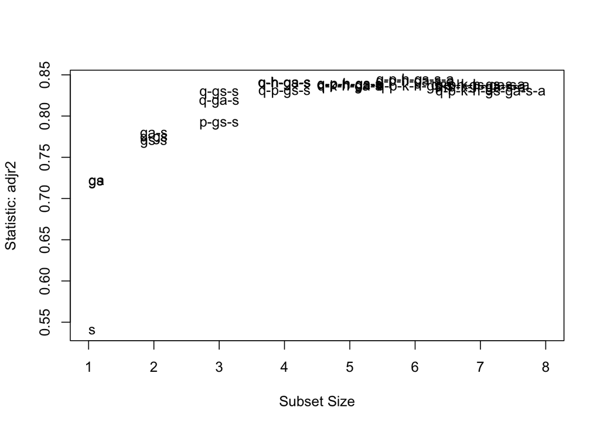

```
##        Abbreviation
## quartz            q
## plag              p
## kfds              k
## hb                h
## gs               gs
## ga               ga
## sf                s
## ar                a
```

```r
subsets(fit.subs, statistic="adjr2", legend=FALSE)
```

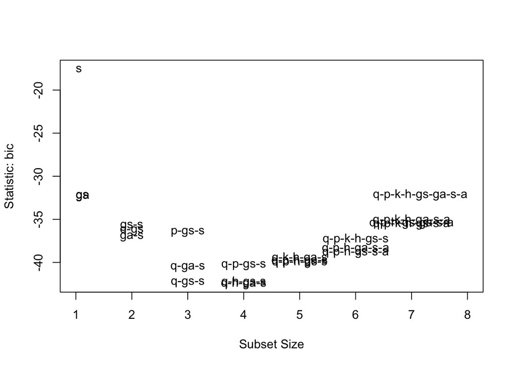

```
##        Abbreviation
## quartz            q
## plag              p
## kfds              k
## hb                h
## gs               gs
## ga               ga
## sf                s
## ar                a
```

```r
subsets(fit.subs, statistic="bic", legend=FALSE)
```

These plots are very handy (albeit aethestically ugly … you can find more attractive plots in the textbook). We look for inflection points (where the bend occurs) in the pattern. It sure seems to be around the 3 or 4 subset models.

Let’s run the algorithm again focusing on the best models with at most 4 predictor variables.

```r
summary(regsubsets(formula(full.fit), data=rocks, nbest=1, nvmax=4))
```

```
## Subset selection object
## Call: regsubsets.formula(formula(full.fit), data = rocks, nbest = 1,
##     nvmax = 4)
## 8 Variables  (and intercept)
##        Forced in Forced out
## quartz     FALSE      FALSE
## plag       FALSE      FALSE
## kfds       FALSE      FALSE
## hb         FALSE      FALSE
## gs         FALSE      FALSE
## ga         FALSE      FALSE
## sf         FALSE      FALSE
## ar         FALSE      FALSE
## 1 subsets of each size up to 4
## Selection Algorithm: exhaustive
##          quartz plag kfds hb  gs  ga  sf  ar
## 1  ( 1 ) " "    " "  " "  " " " " "*" " " " "
## 2  ( 1 ) " "    " "  " "  " " " " "*" "*" " "
## 3  ( 1 ) "*"    " "  " "  " " "*" " " "*" " "
## 4  ( 1 ) "*"    " "  " "  "*" " " "*" "*" " "
```

The *best* model with 4 terms has `quartz`, `hb`, `ga` and `sf`. The *best* model with 3 terms has `quartz`, `gs` and `sf`.

Note that we built similar models above using forward selection and backward selection. Let’s compare these two models.

```r
fit.best3 <- lm(UCS ~ quartz + gs + sf, data=rocks)
fit.best4 <- lm(UCS ~ quartz + hb + ga + sf, data=rocks)
summary(fit.best3)
```

```
##
## Call:
## lm(formula = UCS ~ quartz + gs + sf, data = rocks)
##
## Residuals:
##      Min       1Q   Median       3Q      Max
## -12.4380  -1.5774   0.2358   2.4691   8.0150
##
## Coefficients:
##              Estimate Std. Error t value Pr(>|t|)
## (Intercept)   52.3035    19.9815   2.618  0.01457 *
## quartz         0.5260     0.1642   3.203  0.00357 **
## gs          -527.8994   103.3729  -5.107 2.54e-05 ***
## sf            80.7176    26.0369   3.100  0.00461 **
## ---
## Signif. codes:  0 '***' 0.001 '**' 0.01 '*' 0.05 '.' 0.1 ' ' 1
##
## Residual standard error: 4.441 on 26 degrees of freedom
## Multiple R-squared:  0.8452, Adjusted R-squared:  0.8273
## F-statistic: 47.31 on 3 and 26 DF,  p-value: 1.137e-10
```

```r
AIC(fit.best3)
```

```
## [1] 180.2937
```

```r
BIC(fit.best3)
```

```
## [1] 187.2997
```

```r
summary(fit.best4)
```

```
##
## Call:
## lm(formula = UCS ~ quartz + hb + ga + sf, data = rocks)
##
## Residuals:
##      Min       1Q   Median       3Q      Max
## -12.4730  -1.6183   0.6566   2.2282   7.1558
##
## Coefficients:
##              Estimate Std. Error t value Pr(>|t|)
## (Intercept) 36.498319  18.303694   1.994  0.05716 .
## quartz       0.497235   0.163998   3.032  0.00559 **
## hb           0.332798   0.151448   2.197  0.03747 *
## ga          -0.006855   0.002102  -3.262  0.00319 **
## sf          80.906406  24.715114   3.274  0.00310 **
## ---
## Signif. codes:  0 '***' 0.001 '**' 0.01 '*' 0.05 '.' 0.1 ' ' 1
##
## Residual standard error: 4.273 on 25 degrees of freedom
## Multiple R-squared:  0.8622, Adjusted R-squared:  0.8401
## F-statistic:  39.1 on 4 and 25 DF,  p-value: 2.051e-10
```

```r
AIC(fit.best4)
```

```
## [1] 178.8019
```

```r
BIC(fit.best4)
```

```
## [1] 187.2091
```

Given that $R^2_a$ is better, and the AIC and BIC values are also better for the model with the 4 terms, we would argue it is better.

## Summary

By backward selection, we chose the model

```r
step.pick
```

```
##
## Call:
## lm(formula = UCS ~ quartz + plag + hb + gs + sf + ar, data = rocks)
##
## Coefficients:
## (Intercept)       quartz         plag           hb           gs           sf
##      7.8308       0.4762       0.6784       0.3146    -414.4010      67.8523
##          ar
##     60.2537
```

and by forward selection and the best subsets approach, we chose

```r
step.pick.forward
```

```
##
## Call:
## lm(formula = UCS ~ ga + sf + quartz + hb, data = rocks)
##
## Coefficients:
## (Intercept)           ga           sf       quartz           hb
##   36.498319    -0.006855    80.906406     0.497235     0.332798
```

From our earlier analysis, it appears either `gs` or `ga` are nearly equivalent and valid. So what about a similar model with `gs` instead of `ga`?

```r
another.fit <- lm(UCS ~ quartz + hb + sf + gs, data=rocks)
summary(another.fit)
```

```
##
## Call:
## lm(formula = UCS ~ quartz + hb + sf + gs, data = rocks)
##
## Residuals:
##     Min      1Q  Median      3Q     Max
## -13.003  -2.255   1.028   2.131   7.561
##
## Coefficients:
##              Estimate Std. Error t value Pr(>|t|)
## (Intercept)   43.3390    19.9874   2.168  0.03985 *
## quartz         0.5521     0.1592   3.467  0.00192 **
## hb             0.2764     0.1620   1.707  0.10029
## sf            78.7295    25.1561   3.130  0.00441 **
## gs          -401.3025   124.3249  -3.228  0.00347 **
## ---
## Signif. codes:  0 '***' 0.001 '**' 0.01 '*' 0.05 '.' 0.1 ' ' 1
##
## Residual standard error: 4.286 on 25 degrees of freedom
## Multiple R-squared:  0.8613, Adjusted R-squared:  0.8391
## F-statistic: 38.82 on 4 and 25 DF,  p-value: 2.214e-10
```

```r
AIC(another.fit)
```

```
## [1] 178.9879
```

```r
BIC(another.fit)
```

```
## [1] 187.395
```

We can summarize the fits with code such as the following:

```r
tab <- data.frame(Adj.R.Squared = c(summary(full.fit)$adj.r.squared, summary(step.pick)$adj.r.squared, summary(step.pick.forward)$adj.r.squared, summary(another.fit)$adj.r.squared),
                  AIC=c(AIC(full.fit), AIC(step.pick), AIC(step.pick.forward), AIC(another.fit)),
                  BIC=c(BIC(full.fit), BIC(step.pick), BIC(step.pick.forward), BIC(another.fit)) )
rownames(tab) <- c("Full: quartz-plag-kfds-hb-gs-ga-sf-ar",
                   "Backward: quartz-plag-hb-gs-sf-ar",
                   "Forward & Subsets: quartz-hb-ga-sf",
                   "Other: quartz-hb-gs-sf")
kable(tab)
```

|  | Adj.R.Squared | AIC | BIC |
| --- | --- | --- | --- |
| Full: quartz-plag-kfds-hb-gs-ga-sf-ar | 0.8296093 | 183.4856 | 197.4976 |
| Backward: quartz-plag-hb-gs-sf-ar | 0.8434733 | 179.6688 | 190.8783 |
| Forward & Subsets: quartz-hb-ga-sf | 0.8401424 | 178.8019 | 187.2091 |
| Other: quartz-hb-gs-sf | 0.8391484 | 178.9879 | 187.3950 |

**Which model should we use?**

There is no *correct* answer to this question! These tools are exactly that … *tools*. They help us, the practitioner, choose the model!

Based on all the above, the one finding that appears consistent is that the full-fit model is less than ideal. The other three models have comparable performance (all measures are fairly close) with BIC separating the backward selection method from the others.

If we needed to make a decision based on what has been presented, we would use a model with `quartz`, `hb`, `sf` and `ga`; it has the second-largest $R^2_a$ (and only 0.003 less than the largest), and smallest AIC and BIC of those considered. We will see another method to compare models next week.